# Memo: Sustainability Science Citation Analysis (v1)

Wyatt Hurt

03/16/2020

As requested by Alicia Harley on March 11, this paper provides a broad-scope analysis of the citations in *Sustainability Science: Toward a Synthesis (Harvard Sustainability Science Program Working Paper 2019-01)*. I would be happy to expand upon any sections of this memo further, if it would be helpful.

## Method

I used a [REF extractor script](https://rintze.zelle.me/ref-extractor/) to extract the Zotero citations from the paper’s .docx file. Then, I extracted the DOIs from this file and imported them into Web of Science, creating a marked list, which I exported to a .bib file. From there, I read the .bib file into R and analyzed it using the [bibliometrix() package](https://www.bibliometrix.org/).

The original paper cites 420 articles, 246 of which had DOIs assigned within our shared sust_sci Zotero. This memo only analyzes the 246 articles which had DOIs assigned. I would be happy to manually assign DOIs to the appropriate Zotero articles and re-run the analysis script, if that would be helpful.

Please use the tabs below to navigate through the different metrics. And, please excuse the rather messy formatting in some places (I am learning R, and am still trying to understand the nuances of presenting data outside of the Microsoft Office Suite).

## First-Order Citation Trends

### Temporal Trends

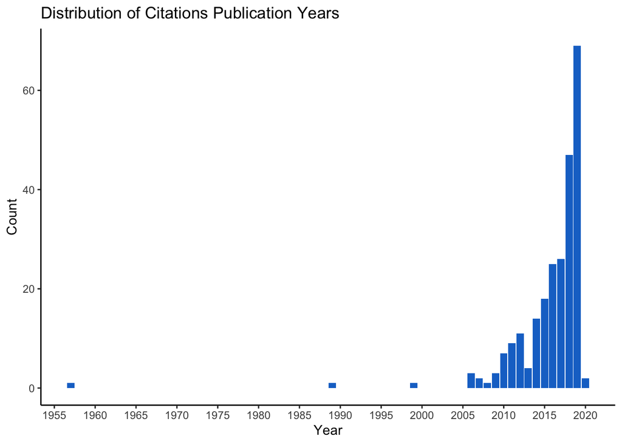

### Authors

This list includes all authors listed on all citations (not just first or second authors) that were cited more than twice by Clark and Harley (2019).

Most Frequently Cited Authors<sup>1</sup>

| Author Name | Times Cited |
| --- | --- |
| FOLKE C | 13 |
| ADGER WN | 8 |
| ANDERIES JM | 8 |
| BIGGS R | 8 |
| SCHEFFER M | 8 |
| CARPENTER SR | 7 |
| OSTROM E | 6 |
| POLASKY S | 6 |
| AVELINO F | 5 |
| BROWN K | 5 |
| CLARK WC | 5 |
| LAMBIN EF | 5 |
| VAN NES EH | 5 |
| BARBIER EB | 4 |
| CHOWDHURY RR | 4 |
| DIAZ S | 4 |
| GEELS FW | 4 |
| PITTMAN J | 4 |
| ROCHA JC | 4 |
| WALKER B | 4 |
| YOUNG OR | 4 |
| ALEXANDER SM | 3 |
| BRONDIZIO ES | 3 |
| CORNELL SE | 3 |
| CREPIN AS | 3 |
| DAKOS V | 3 |
| EAKIN H | 3 |
| FRANTZESKAKI N | 3 |
| GALAZ V | 3 |
| JANSSEN MA | 3 |
| LEVIN SA | 3 |
| LIU J | 3 |
| LOORBACH D | 3 |
| MAZZUCATO M | 3 |
| MORRISON TH | 3 |
| PETERSON GD | 3 |
| RAVEN R | 3 |
| REYERS B | 3 |
| ROCKSTROM J | 3 |
| SCHLUTER M | 3 |
| SCHOT J | 3 |
| SITAS N | 3 |
| STEFFEN W | 3 |
| TURNER BL | 3 |
| VAN DE LEEMPUT IA | 3 |
| VAN KERKHOFF L | 3 |
| WITTMAYER JM | 3 |

<sup>*1*</sup> All scholars cited more than 2 times are listed.

### Geographies

Following standard bibliometric procedure, I use the corresponding author’s “affiliated country” in Web of Science to assign a country ID to each citation. The table below lists all countries cited by Clark and Harley (2019).

Most Frequently Cited Countries

| Country | Times Cited |
| --- | --- |
| USA | 105 |
| UNITED KINGDOM | 30 |
| SWEDEN | 23 |
| NETHERLANDS | 18 |
| AUSTRALIA | 14 |
| GERMANY | 9 |
| NORWAY | 6 |
| SWITZERLAND | 6 |
| CANADA | 5 |
| AUSTRIA | 4 |
| BELGIUM | 4 |
| FRANCE | 4 |
| SOUTH AFRICA | 4 |
| ARGENTINA | 2 |
| SPAIN | 2 |
| BRAZIL | 1 |
| CHINA | 1 |
| FINLAND | 1 |
| INDIA | 1 |
| ITALY | 1 |
| JAPAN | 1 |
| NEPAL | 1 |
| NEW ZEALAND | 1 |

### Institutions

Most Frequently Cited Institutions

| Institution | Times Cited |
| --- | --- |
| STOCKHOLM UNIV | 13 |
| ARIZONA STATE UNIV | 8 |
| HARVARD UNIV | 7 |
| YALE UNIV | 7 |
| INDIANA UNIV | 6 |
| STANFORD UNIV | 6 |
| WAGENINGEN UNIV | 6 |
| ERASMUS UNIV | 5 |
| STELLENBOSCH UNIV | 5 |
| UNIV SUSSEX | 5 |
| NA | 5 |
| COLORADO STATE UNIV | 4 |
| UNIV CALIF BERKELEY | 4 |
| UNIV MANCHESTER | 4 |
| UNIV OSLO | 4 |
| JAMES COOK UNIV | 3 |
| LUND UNIV | 3 |
| UNIV ARIZONA | 3 |
| UNIV CALIF SANTA BARBARA | 3 |
| UNIV E ANGLIA | 3 |
| UNIV MINNESOTA | 3 |

### Journals

The table below lists all journals cited more than once by Clark and Harley (2019).

Most Cited Journals<sup>1</sup>

| Journal | Times Cited |
| --- | --- |
| PROCEEDINGS OF THE NATIONAL ACADEMY OF SCIENCES OF THE UNITED STATES OF AMERICA | 24 |
| ECOLOGY AND SOCIETY | 13 |
| GLOBAL ENVIRONMENTAL CHANGE-HUMAN AND POLICY DIMENSIONS | 13 |
| SCIENCE | 11 |
| ENVIRONMENTAL RESEARCH LETTERS | 9 |
| NATURE SUSTAINABILITY | 9 |
| CURRENT OPINION IN ENVIRONMENTAL SUSTAINABILITY | 8 |
| ENVIRONMENTAL SCIENCE \& POLICY | 8 |
| RESEARCH POLICY | 8 |
| SUSTAINABILITY | 8 |
| CLIMATIC CHANGE | 7 |
| ANNUAL REVIEW OF ENVIRONMENT AND RESOURCES VOL 43 | 5 |
| WORLD DEVELOPMENT | 5 |
| ANNUAL REVIEW OF ENVIRONMENT AND RESOURCES VOL 42 | 4 |
| ENERGY RESEARCH \& SOCIAL SCIENCE | 4 |
| ENVIRONMENTAL INNOVATION AND SOCIETAL TRANSITIONS | 4 |
| POLICY AND SOCIETY | 4 |
| AMBIO | 3 |
| ANNUAL REVIEW OF ENVIRONMENT AND RESOURCES | 3 |
| ANNUAL REVIEW OF ENVIRONMENT AND RESOURCES VOL 36 | 3 |
| ANNUAL REVIEW OF ENVIRONMENT AND RESOURCES VOL 41 | 3 |
| INTERNATIONAL JOURNAL OF THE COMMONS | 3 |
| ANNUAL REVIEW OF ENVIRONMENT AND RESOURCES VOL 35 | 2 |
| ANNUAL REVIEW OF ENVIRONMENT AND RESOURCES VOL 37 | 2 |
| ANNUAL REVIEW OF ENVIRONMENT AND RESOURCES VOL 40 | 2 |
| ANNUAL REVIEW OF ENVIRONMENT AND RESOURCES VOL 44 | 2 |
| ANNUAL REVIEW OF POLITICAL SCIENCE VOL 20 | 2 |
| ANNUAL REVIEW OF POLITICAL SCIENCE VOL 21 | 2 |
| ANNUAL REVIEW OF RESOURCE ECONOMICS VOL 6 | 2 |
| ANNUAL REVIEW OF RESOURCE ECONOMICS VOL 8 | 2 |
| ECOLOGICAL ECONOMICS | 2 |
| ECONOMIC JOURNAL | 2 |
| ENVIRONMENTAL \& RESOURCE ECONOMICS | 2 |
| INDUSTRIAL AND CORPORATE CHANGE | 2 |
| POLICY SCIENCES | 2 |
| SUSTAINABILITY SCIENCE | 2 |
| TECHNOLOGICAL FORECASTING AND SOCIAL CHANGE | 2 |
| TRENDS IN ECOLOGY \& EVOLUTION | 2 |

<sup>*1*</sup> Note that Web of Science disaggregates ARER into its separate volumes. This can be corrected with a modification to the R script in future analyses.

### Keywords

The table below lists the author keywords assigned to more than two citations.

Most Cited Keywords<sup>1</sup>

| Keyword | Times Cited |
| --- | --- |
| CLIMATE CHANGE | 41 |
| GOVERNANCE | 34 |
| MANAGEMENT | 33 |
| POLICY | 27 |
| FRAMEWORK | 25 |
| SCIENCE | 24 |
| SYSTEMS | 23 |
| POLITICS | 21 |
| RESILIENCE | 20 |
| SUSTAINABILITY | 20 |
| DYNAMICS | 17 |
| ADAPTATION | 16 |
| ECOSYSTEM SERVICES | 16 |
| KNOWLEDGE | 16 |
| BIODIVERSITY | 14 |
| MULTILEVEL PERSPECTIVE | 14 |
| SOCIAL ECOLOGICAL SYSTEMS | 14 |
| ENERGY | 13 |
| CONSERVATION | 12 |
| LESSONS | 11 |
| ECONOMICS | 10 |
| GROWTH | 10 |
| INSTITUTIONS | 10 |
| UNCERTAINTY | 10 |
| DECISION MAKING | 9 |
| PERSPECTIVE | 9 |
| POWER | 9 |
| VULNERABILITY | 9 |
| COMMONS | 8 |
| COMMUNITY | 8 |

[output cut: 110 more lines]

<sup>*1*</sup> All keywords used more than 2 times are listed.

### Citations

Citations' Most Frequently Cited References<sup>1</sup>

| Article | Cited Reference Count |
| --- | --- |
| ADGER WN, 2006, | 2246 |
| DAHL RA, 1957, | 1514 |
| KABEER N, 1999, | 1029 |
| NELSON DR, 2007, | 879 |
| MARKARD J, 2012, | 834 |
| SCHEFFER M, 2012, | 736 |
| OSTROM E, 2010, | 711 |
| O'REILLY CA, 2008, | 656 |
| MANI A, 2013, | 594 |
| DIAZ S, 2015, | 583 |
| SCOONES I, 2009, | 533 |
| OSTROM E, 2011, | 442 |
| CHAPIN FS, 2010, | 415 |
| OSTROM E, 2007, | 399 |
| TILMAN D, 2014, | 394 |
| BIGGS R, 2012, | 346 |
| O'BRIEN K, 2012, | 344 |
| WISE RM, 2014, | 338 |
| MCGINNIS MD, 2014, | 306 |
| COLLINS PH, 2015, | 286 |
| PASCUAL U, 2017, | 261 |
| MEYFROIDT P, 2011, | 261 |
| POLASKY S, 2011, | 260 |
| TENGO M, 2014, | 257 |
| BRONDIZIO ES, 2009, | 257 |
| LAWLER JJ, 2014, | 250 |
| STEFFEN W, 2018, | 245 |
| PEATTIE K, 2010, | 221 |
| BROWN K, 2011, | 209 |
| ARROW KJ, 2012, | 203 |
| ERIKSEN SH, 2015, | 173 |
| CLARK WC, 2016, -a | 169 |
| HANSEN T, 2015, | 167 |
| FOXON TJ, 2011, | 163 |
| LE BLANC D, 2015, | 161 |
| BETTENCOURT LMA, 2011, | 158 |
| LEISEROWITZ AA, 2006, | 153 |
| CLARK WC, 2016, | 150 |
| MARSHALL NA, 2012, | 132 |
| ANDERIES JM, 2013, | 129 |
| YOUNG OR, 2011, | 118 |
| SCHAFFARTZIK A, 2014, | 115 |
| NORDHAUS WD, 2017, | 108 |
| HOLDEN E, 2014, | 108 |
| GEELS FW, 2017, | 107 |
| CARPENTER SR, 2012, | 105 |
| CLEMENT F, 2010, | 105 |
| SCHEFFER M, 2015, | 104 |
| GEELS FW, 2015, | 95 |
| SEN A, 2013, | 94 |
| HICKS CC, 2016, | 92 |
| MILANOVIC B, 2011, | 91 |
| SETO KC, 2016, | 86 |
| CHOWDHURY RR, 2006, | 85 |
| EPSTEIN G, 2015, | 84 |
| ANDONOVA LB, 2010, | 80 |
| AGYEMAN J, 2016, | 78 |
| LOORBACH D, 2017, | 74 |
| WELLS P, 2012, | 72 |
| VAN KERKHOFF LE, 2015, | 71 |
| WALKER B, 2010, | 71 |
| DALTON PS, 2016, | 63 |
| MARQUIS C, 2016, | 61 |
| BINZ C, 2017, | 57 |
| CARPENTER SR, 2015, | 56 |
| SCHOT J, 2018, | 54 |
| FISCHER LB, 2016, | 53 |
| MANSBRIDGE J, 2014, | 52 |
| WILSON S, 2013, | 51 |
| ASHEIM GB, 2010, | 50 |

## Network Analysis

Using elementary machine learning, this section analyzes the connections between citations.

### Co-Citation Network

Following the approach of Batagelj & Cerinsek (2013) and Aria & Cuccurullo (2017), I conducted co-citation analysis. The network plot shows the 30 articles from the Clark and Harley (2019) “pool” that have been most frequently cited by other articles from the “pool.” Note that there are two distinct clusters of articles, indicating that there are two groups of authors speaking to one another, with relatively sparse citations occuring between the two groups.

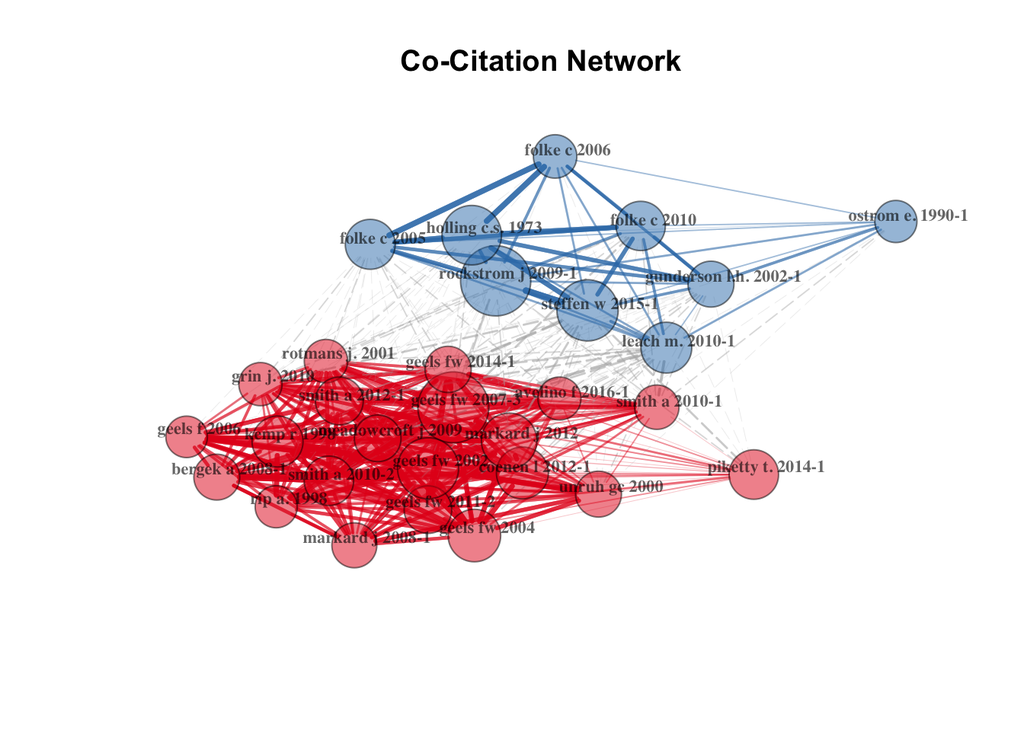

### Conceptual Structure Map

Following the approach of Aria & Cuccurullo (2017), I conducted conceptual structure analysis (using correspondence analysis methods).

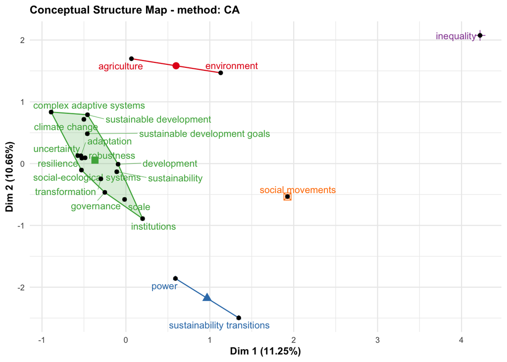

### Historical Citation Network

```
## Articles analysed   100
## Articles analysed   143
```

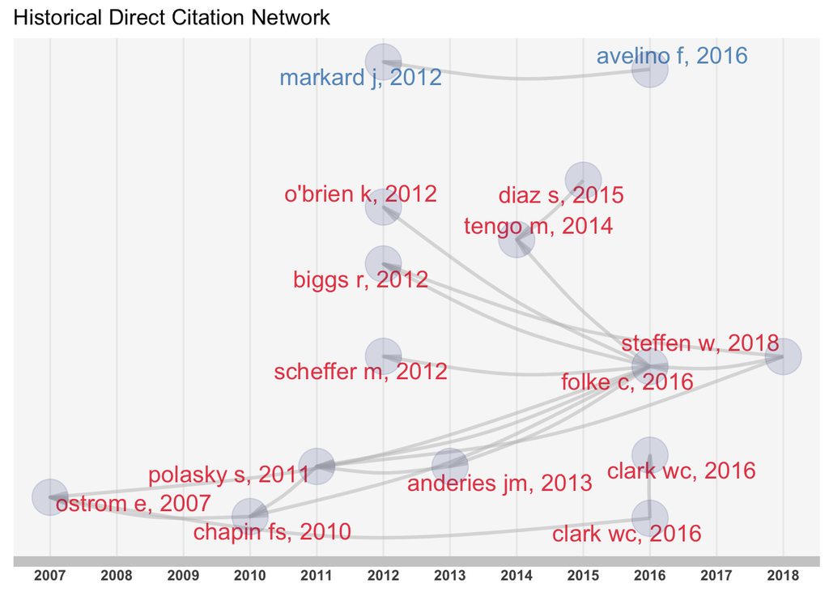

```
##
##  Legend
##
##                          Paper                                   DOI Year LCS GCS
## 2007 - 7      OSTROM E, 2007,                10.1073/PNAS.0701886104 2007  18 399
## 2010 - 13     OSTROM E, 2010,        10.1016/J.GLOENVCHA.2010.07.004 2010  10 711
## 2010 - 15    CHAPIN FS, 2010,             10.1016/J.TREE.2009.10.008 2010   8 415
## 2011 - 23    POLASKY S, 2011,             10.1016/J.TREE.2011.04.007 2011  10 260
## 2012 - 32   SCHEFFER M, 2012,                10.1126/SCIENCE.1225244 2012   8 736
## 2012 - 33    O'BRIEN K, 2012,               10.1177/0309132511425767 2012  11 344
## 2012 - 36    MARKARD J, 2012,           10.1016/J.RESPOL.2012.02.013 2012  17 834
## 2012 - 37     ARROW KJ, 2012,              10.1017/S1355770X12000137 2012  11 203
## 2012 - 39      BIGGS R, 2012,  10.1146/ANNUREV-ENVIRON-051211-123836 2012  10 346
## 2013 - 42  ANDERIES JM, 2013,                10.5751/ES-05178-180208 2013   9 129
## 2014 - 45      TENGO M, 2014,              10.1007/S13280-014-0501-3 2014   9 257
## 2015 - 65       DIAZ S, 2015,           10.1016/J.COSUST.2014.11.002 2015  10 583
## 2016 - 77    AVELINO F, 2016,          10.1080/1523908X.2015.1112259 2016  11  27
## 2016 - 81     CLARK WC, 2016,                10.1073/PNAS.1601266113 2016  10 150
## 2016 - 82   CLARK WC, 2016, -a               10.1073/PNAS.0900231108 2016  10 169
## 2016 - 91      FOLKE C, 2016,                10.5751/ES-09088-210444 2016  11  32
## 2018 - 125   STEFFEN W, 2018,                10.1073/PNAS.1810141115 2018   8 245
```

### Country Collaboration

Finally, I analyzed how authors were collaborating with one another across countries. Using the Web of Science “country affiliation” of all authors of each co-authored paper, I conducted network analysis to answer the following question: When a paper is co-authored, which countries do its co-authors originate from? Thicker lines between the countries below indicate that more scholars from those respective countries co-authored papers together in the Clark and Harley (2019) “pool.” Larger circles around a country name indicate that country had more affiliated authors in the Clark and Harley (2019) “pool.”

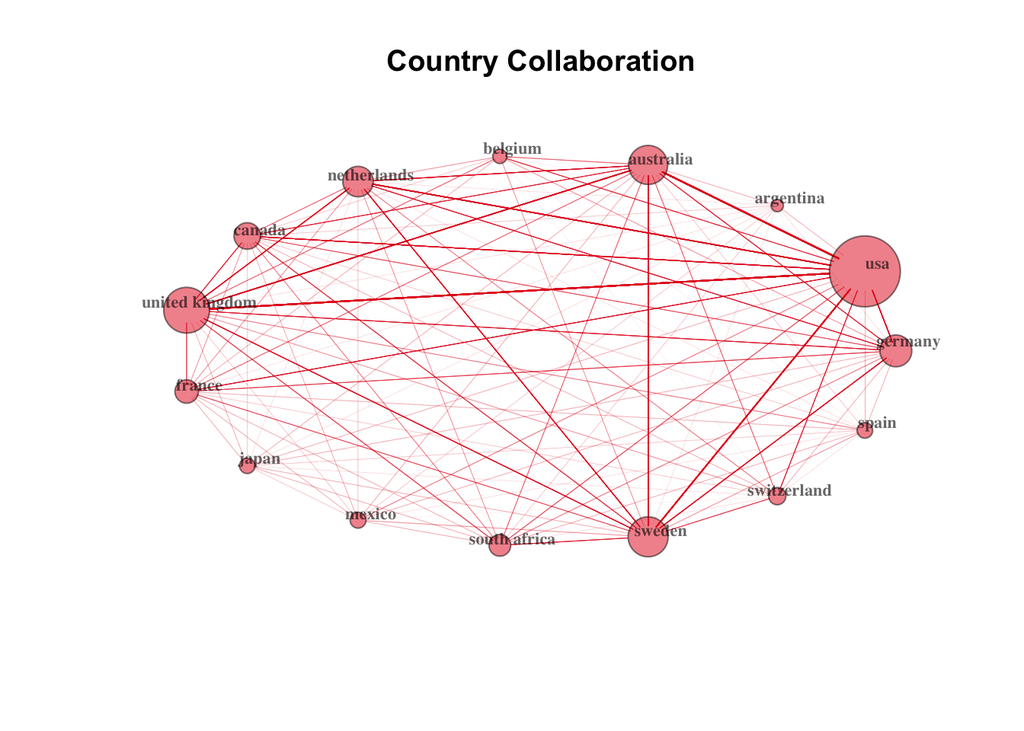

## Conclusion

With the power of R and the bibliometrix() package, it is possible to answer almost any bibliometric question that could possibly be asked with just a few lines of code. Please let me know if I can be helpful in answering other questions.